# US Covid-19 Data Tracker

# Author - YASH BAJAJ

## 1.Data Description

The use of data science methodologies in medicine and public health has been enabled by the wide availability of big data of human mobility, contact tracing, medical imaging, virology, drug screening, bioinformatics, electronic health records and scientific literature, along with the ever-growing computing power. With these advances, the huge passion of researchers and practitioners, and the urgent need for data-driven insights, during the ongoing coronavirus disease 2019 (COVID-19) pandemic, data science has played a key role in understanding and combating the pandemic more than ever.

For our project, we will use 3 datasets which will be pulled from Center for Disease Control and Prevention's website -

# 2.Variables -

- US COUNTY -
1. Recip State(type:object) - Recipient State.
2. Date(type:Datetime) - Date.
3. FIPS(type:string) - Federal Information Processing Standards code.
4. Series_Complete_Pop_Pct(type:float64) - Percent of people who are fully vaccinated (have second dose of a two-dose vaccine or one dose of a single-dose vaccine) based on the jurisdiction and county where recipient lives.
5. Administered_Dose1_Pop_Pct(type:float64) - Percent of Total Pop with at least one Dose by State of Residence.
- US TRANSMISSION -
1. Report Date(type:Datetime) - Date county level of community transmission indicator reported on COVID Data Tracker.
2. state_name(type:object) - Jurisdiction (state/territory) where vaccine recipient lives.
3. county_name(type:object) - County where vaccine recipient lives.
4. percent_test_results_reported_positive_last_7_days(type:float64) - Percentage of positive diagnostic and screening nucleic acid amplification tests (NAAT) during the last 7 days.
5. cases_per_100K_7_day_count_change(type:float32) - Total number of new cases per 100,000 persons within the last 7 days.
- US JURISDICTION -
1. Date(type:Datetime) - Date of Administered Dose.
2. Location(type:object) - State/Territory/Federal Entity.
3. Series_Complete_Pop_Pct(type:float64) - Percent of people who are fully vaccinated (have second dose of a two-dose vaccine or one dose of a single-dose vaccine) based on the jurisdiction where recipient lives.
4. Administered_Dose1_Pop_Pct(type:float64) - Percent of population with at lease one dose based on the jurisdiction where recipient lives.

# 3.Question of Interest

Our main aim is to visualize the data extracted from the CDC's website using Dash and Plotly. For this we have divided our website into a few components which will represent different outputs. They are as follows -

- Choropleth map with each state colored by the vaccination percentage. There are 2 inputs for this graph: whether the vaccination percentage is for fully vaccinated or at least 1 dose, and a slider for the vaccine data up to that date.
- A state map with each county colored by the vaccination percentage. There are 3 inputs for this graph: the selected state, whether the vaccination percentage is for fully vaccinated or at least 1 dose, and a slider for the vaccine data up to that date.
- A time series chart for the daily positive test result percentage (7-day moving averages) in the selected county. There are 3 inputs for this graph: the selected state, the selected county, and a range slider to select the start and end date.
- A time series chart for the daily number of new cases per 100K (7-day moving averages) in the selected county. There are 3 inputs for this graph: the selected state, the selected county, and a range slider to select the start and end date.

# 4.Testing of the webapp

We will test the app by selecting different values for different set of inputs to get our outputs -

**Map1: Selecting 'Fully Vacinnated' Radio Button till date '06/11/2021' -**

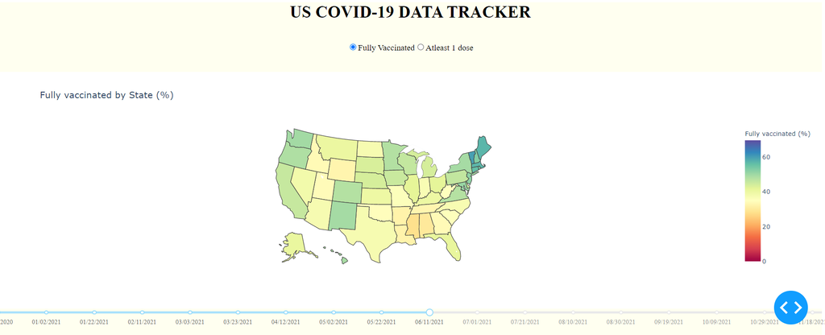

**Map1: Selecting 'Atleast 1 dose' Radio Button till date '08/30/2021'**

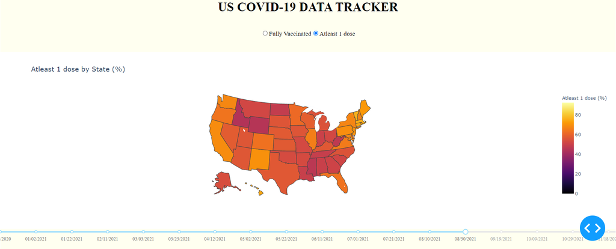

**Map2: Selecting 'Fully Vacinnated' Radio Button for Oregon State and Baker County till date '10/09/2021' -**

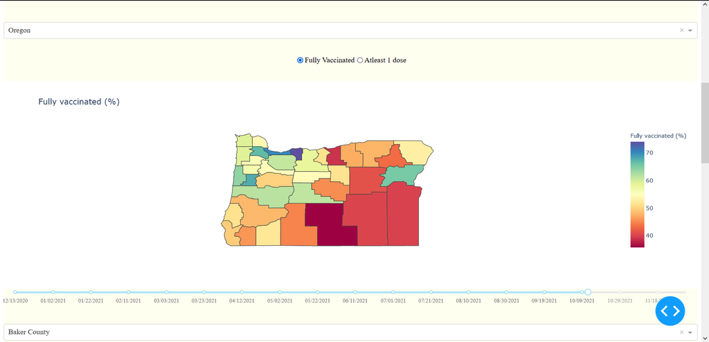

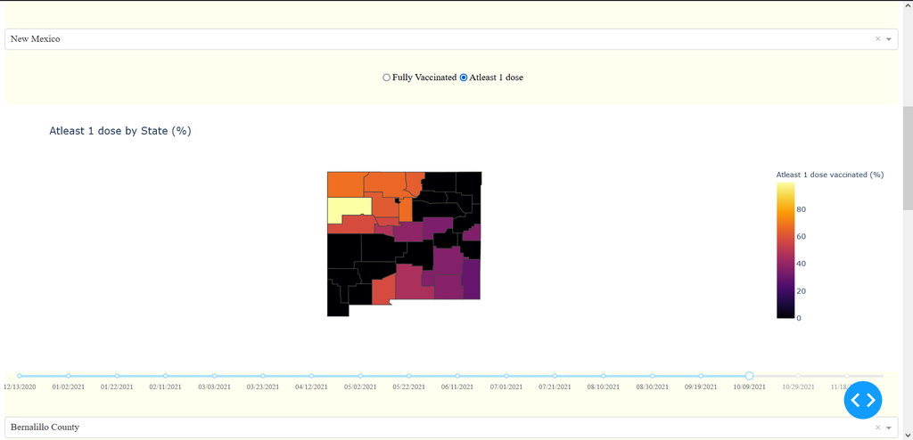

**Time Series Chart1: Using County 'Albany',State 'New York' and Date from '08/22/2021' to '11/10/2021'**

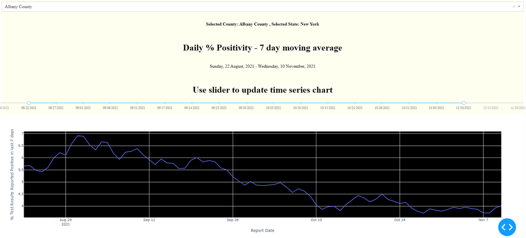

**Time Series Chart2: Using County 'Anderson',State 'Tennessee' and Date from '08/27/2021' to '10/10/2021'**

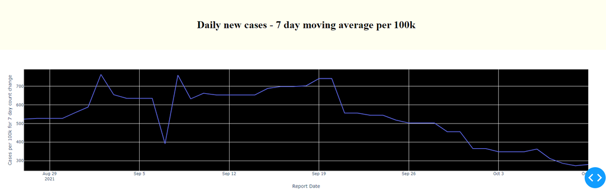

# 5. Conclusion and Discussion -

We were successfully able to visualize the Covid-19 Vaccinations for people who have received both the doses or at least a single dose for states and their respective counties in the USA. We have also visualized the trends in transmission of Covid-19 in each state and county using a time-series 7 day moving average chart. The next steps would be to plot pairs of predictors with response to check their relationship with each other, perform diagnostics to check whether the data follows all normality assumptions, fit different Machine Learning Algorithms, compare them and then use the best model which has the best training and prediction accuracy along with the lowest Root Mean Square Error value.